# Seldin Report: Ssec Scores

Angela Yoder

2022-07-14

**The goals of this program are:**

This report will document the results of the fix implemented to the biweight midcorrelation calculation of Ssec scores. Liver and brain datasets were verified to be in the same strain order in this report.

## Density Plots

Below are the density plots comparing the distributions of tissue-exclusive, secreted (TES) protein-coding genes and tissue-exclusive, non-secreted (TENS) protein-coding genes for both brain and liver. The plots for brain are fairly similar, however there is a slight bump at the right hand side of the plot where TES protein-coding genes have a higher density.

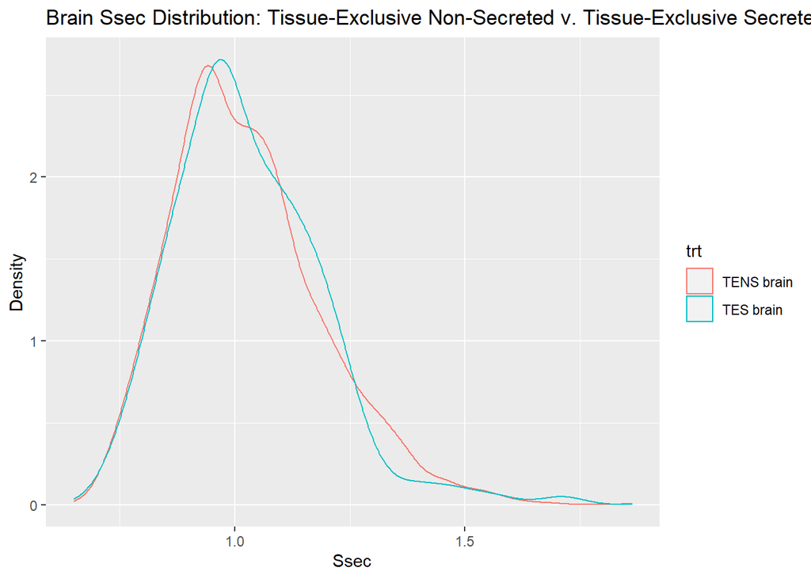

[figure not shown]

## Histograms

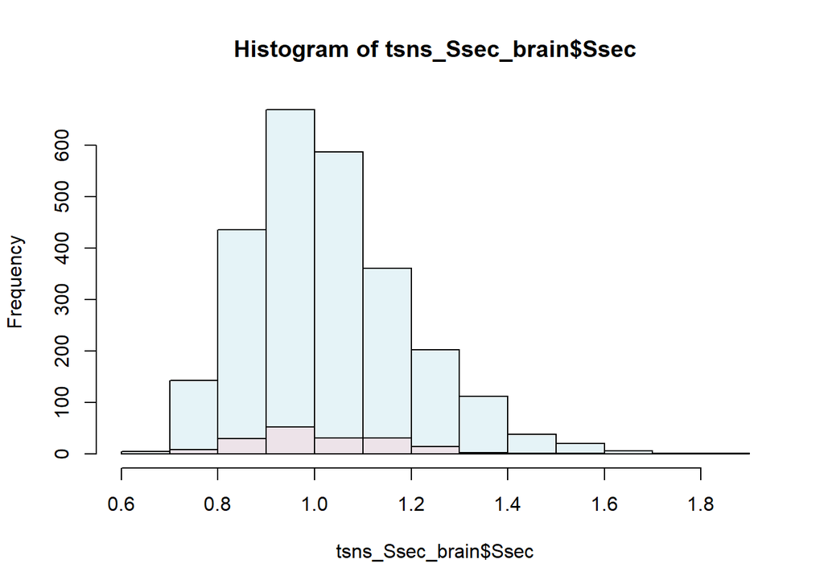

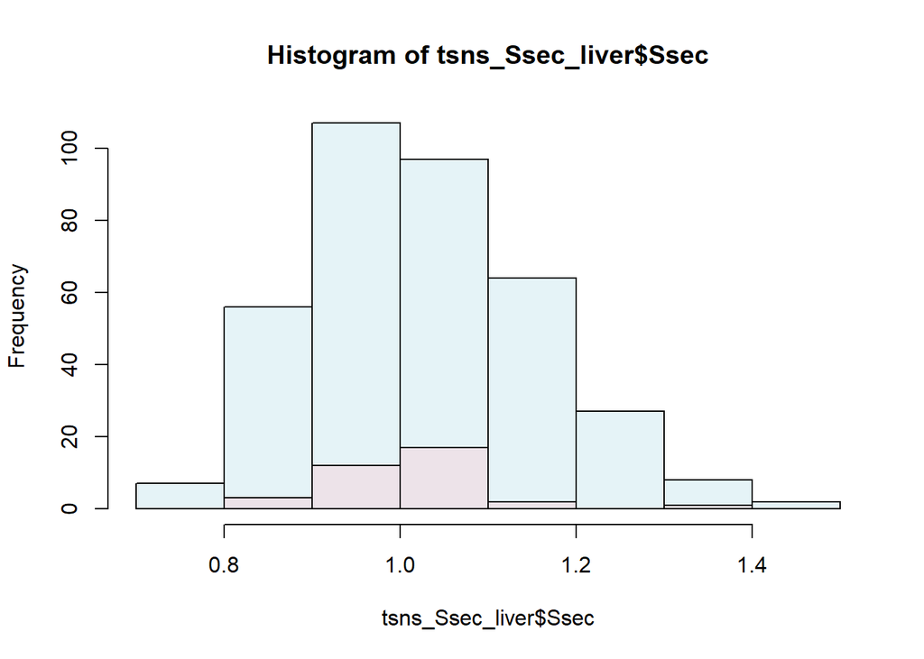

The plots for liver differ more dramatically, likely due to the small sample size for TES protein-coding genes in the liver. We continue to see a small bump in the lower right that may be promising.

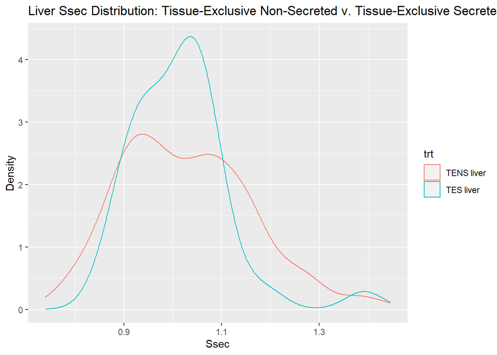

[figure not shown]

[figure not shown]

[figure not shown]

## QQ Plots

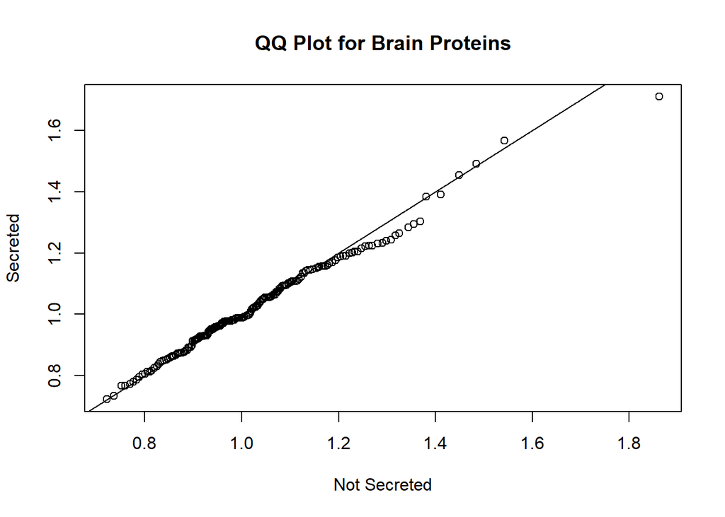

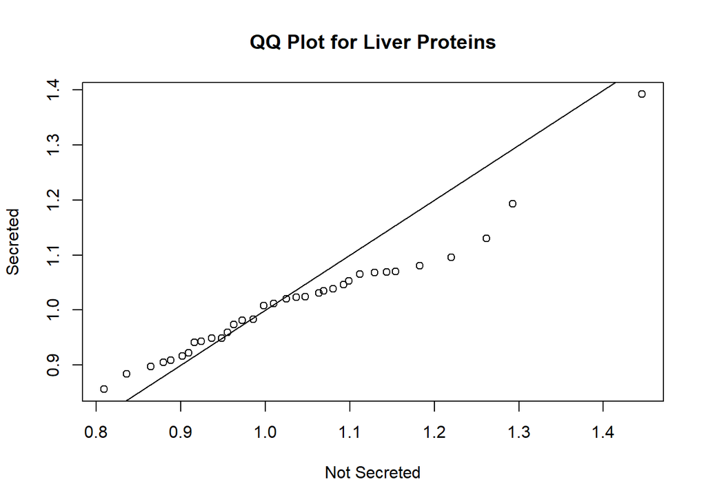

## Selecting Relavent TES Protein-Coding Genes

Because our QQ plots are less than satisfactory, we will determine our top Ssec scores by selecting all TES protein-coding genes that have a higher Ssec score than the 95th percentile of Ssec scores for TENS protein-coding genes in the respective tissues. This results in the following six genes for brain and one gene for liver.

TES Protein-Coding Genes in the Brain that have higher Ssec scores than the 95th quantile of TENS protein-Coding Genes from the Brain

| Gene | Gene_Symbol | Ssec_Score | Number_Target_Genes | eQTL_FDR | eQTL_pval |
| --- | --- | --- | --- | --- | --- |
| ENSRNOG00000005652 | Cntn4 | 1.709393 | 72 | 0.3537692 | 0.035 |
| ENSRNOG00000002548 | Tnn | 1.566616 | 62 | 0.7175745 | 0.152 |
| ENSRNOG00000002381 | Bmp3 | 1.490761 | 52 | 0.7175745 | 0.153 |
| ENSRNOG00000003845 | Wnt3 | 1.454252 | 45 | 0.7175745 | 0.153 |
| ENSRNOG00000059507 | Lamc3 | 1.391114 | 56 | 0.9518740 | 0.537 |
| ENSRNOG00000000010 | Cbln1 | 1.383625 | 49 | 0.6108947 | 0.106 |

TES Protein-Coding Genes in the Liver that have higher Ssec scores than the 95th quantile of TENS Protein-Coding Genes fromt the Liver

| Gene | Gene_Symbol | Ssec_score | Number_Target_Genes | eQTL_FDR | eQTL_pval |
| --- | --- | --- | --- | --- | --- |
| ENSRNOG00000047481 | Kiss1 | 1.392373 | 329 | 0.830778 | 0.672 |

To give a rough estimate of the influence these TES protein-coding genes have in the target tissue, we have plotted the expression of the top TES protein-coding gene against the expression of the four most significantly correlated target genes for each of our top genes. We hope to see defined slope that will indicate the influence these genes have.

### Highest Ssec Score TES Brain and its 4 most correlated liver genes

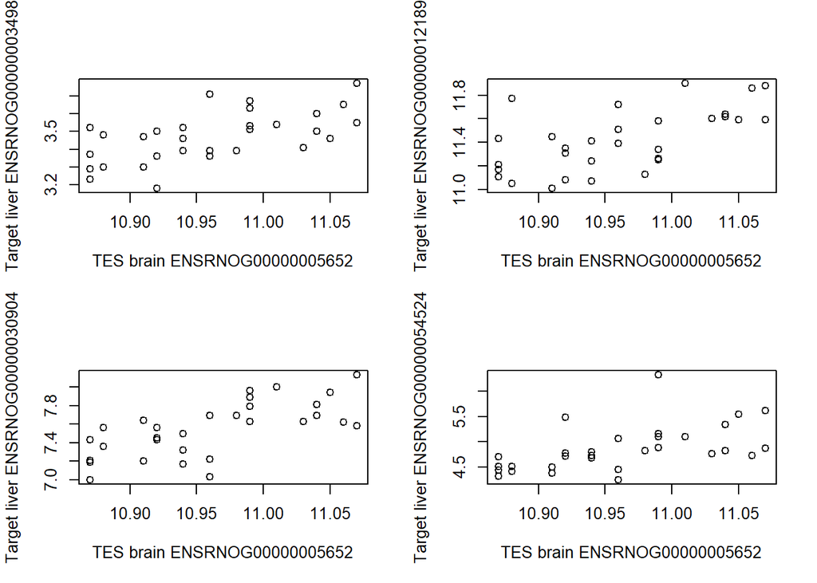

### Second Highest Ssec Score TES Brain and its 4 most correlated liver genes

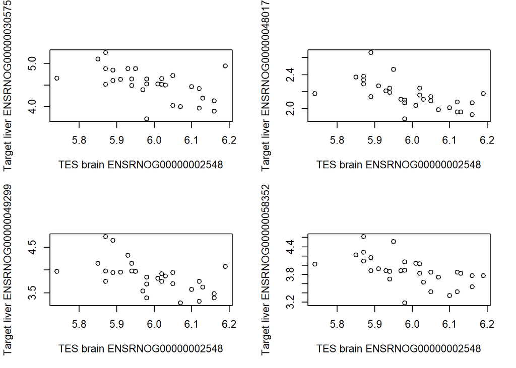

### Third Highest Ssec Score TES Brain and its 4 most correlated liver genes

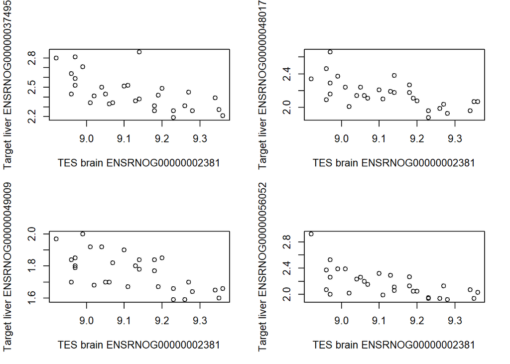

### Fourth Highest Ssec Score TES Brain and its 4 most correlated liver genes

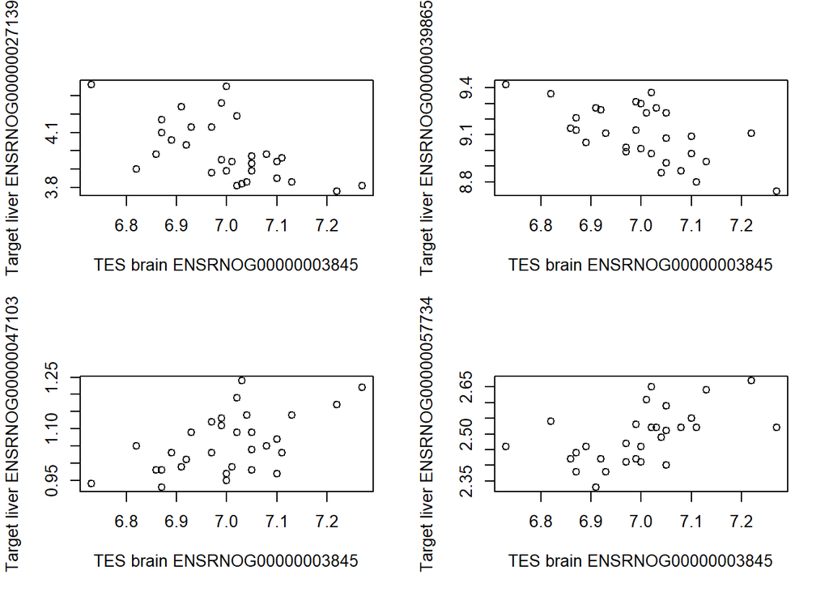

### Fifth Highest Ssec Score TES Brain and its 4 most correlated liver genes

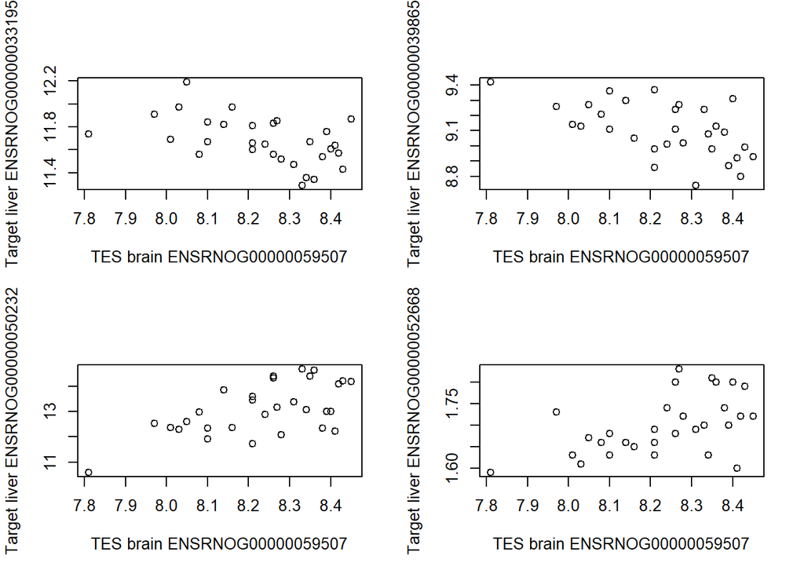

### Sixth Highest Ssec Score TES Brain and its 4 most correlated liver genes

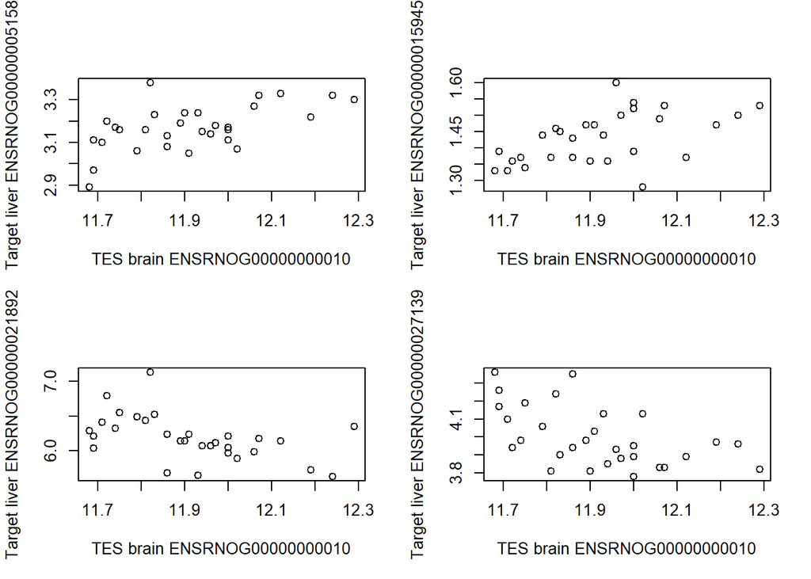

### Highest Ssec Score TES Liver and its 4 most correlated brain genes

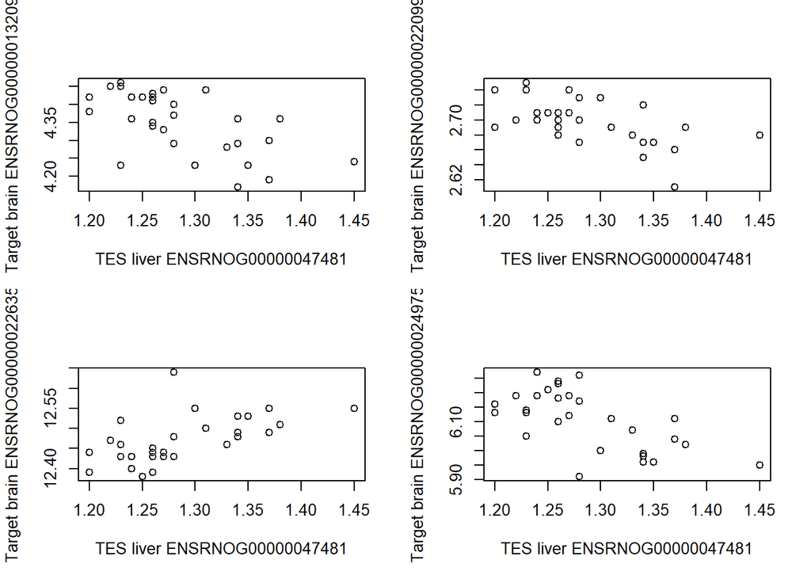

#### Appendix: TES v. All target tissue genes